# Liverpool City Region: the SIA evidence base, then and now

## 9.3 EU framework funding

Under Horizon 2020 (2014-2020), participants in Merseyside received €90.4m, 18th of 41 of the UK’s ITL2 regions (Figure 32). Figure 33 shows Merseyside’s share of the UK’s funding by project start year, against LCR’s 2.3% share of UK population. The UK was not associated to Horizon Europe until January 2024, so UK figures for 2021 to 2023 are low for that reason.

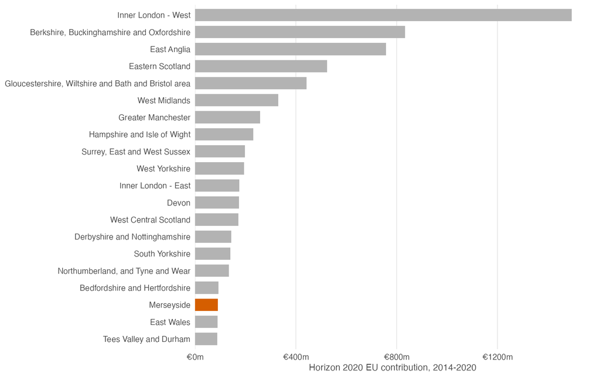

Figure 32: Horizon 2020 funding by ITL2 region, the top 20 and Merseyside. Horizon 2020 EU contribution to participants in each UK ITL2 region (ITL 2021), all years. Participants are placed by their registered address. Source: European Commission, CORDIS Horizon 2020 projects and participants (released 22 September 2026).

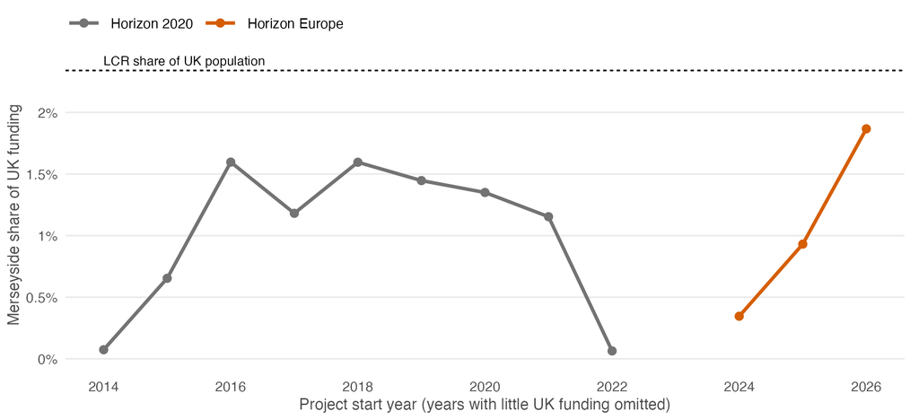

Figure 33: Merseyside’s share of UK EU framework funding, by project start year. Merseyside’s share of the UK’s EU framework funding allocated to regions, by project start year, against LCR’s share of UK population. The UK wasn’t associated to Horizon Europe until January 2024. Source: European Commission, CORDIS Horizon 2020 projects and participants (released 22 September 2026); European Commission, CORDIS Horizon Europe projects and participants (released 22 September 2026); ONS via Nomis, Population estimates (local authority based) (released 29 July 2026).

Table 7: Largest recipients of EU framework funding in Merseyside. Largest recipients of EU contribution in Merseyside, Horizon 2020 and Horizon Europe (euros). Source: European Commission, CORDIS Horizon 2020 projects and participants (released 22 September 2026); European Commission, CORDIS Horizon Europe projects and participants (released 22 September 2026).

| Participant | Horizon 2020 (€m) | Horizon Europe (€m) | Projects |
| --- | --- | --- | --- |
| The University of Liverpool | 74.5 | 39.5 | 225 |
| Liverpool City Council | 2.7 | 0.0 | 2 |
| Buffalogrid Limited | 1.9 | 0.0 | 2 |
| Videregen Limited | 1.6 | 0.0 | 1 |
| Health and Safety Executive | 1.0 | 0.0 | 10 |
| Aimes Grid Services Community Interest Company | 0.9 | 0.0 | 5 |
| Liverpool Heart and Chest Hospital NHS Foundation Trust | 0.9 | 0.0 | 3 |
| Molecular Sense Ltd | 0.8 | 0.0 | 1 |
| Abb Limited | 0.6 | 0.0 | 2 |
| Astech Projects Limited | 0.6 | 0.0 | 1 |
| Karm Research Group Limited | 0.5 | 0.0 | 1 |
| Q Technologies Ltd | 0.5 | 0.0 | 4 |
| Applied Computing & Engineering Limited | 0.5 | 0.0 | 1 |
| Ceratium Limited | 0.5 | 0.0 | 3 |
| Zecora Ura Theatre | 0.0 | 0.5 | 1 |

## 9.4 Innovate UK

Innovate UK awards are an addition: neither SIA1 nor SIA2 used them. Over the last five competition years, LCR participants were offered £129.3m, and awards per head were below England’s in 10 of the 10 years shown (Figure 34). A few large awards dominate: Table 8 lists the largest recipients.

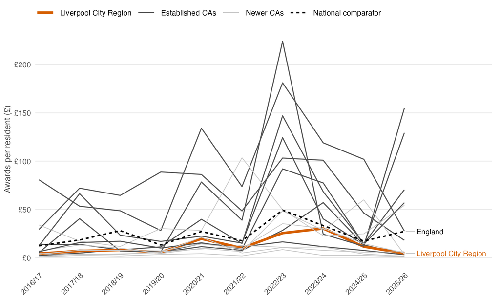

Figure 34: Innovate UK awards per resident. Innovate UK awards offered per resident, by competition financial year, summed from local authorities. Awards are offers, placed at each participant’s main address. Source: UKRI, Innovate UK funded projects since 2004 (released 2 September 2026); ONS via Nomis, Population estimates (local authority based) (released 29 July 2026).

Table 8: Largest recipients of Innovate UK awards in LCR. Largest recipients of Innovate UK awards in LCR, last five competition years. Source: UKRI, Innovate UK funded projects since 2004 (released 2 September 2026).

| Participant | Size | Awards (£m) | Projects |
| --- | --- | --- | --- |
| BIBBY MARINE SERVICES LIMITED | Micro/Small | 19.5 | 5 |
| Inventya Limited | Small | 13.6 | 1 |
| University of Liverpool | Academic | 12.7 | 53 |
| SP MANWEB PLC | Large | 6.2 | 5 |
| STFC - Laboratories | Academic | 6.1 | 23 |
| ULEMCO LTD | Micro/Small | 4.8 | 6 |
| Liverpool John Moores University | Academic | 4.7 | 24 |
| Liverpool School of Tropical Medicine | Academic | 3.8 | 8 |
| CAMMELL LAIRD SHIPREPAIRERS & SHIPBUILDERS LIMITED | Large | 3.6 | 1 |
| University of Greenwich | Academic | 2.9 | 1 |
| GT GREEN TECHNOLOGIES LTD | Micro/Small | 2.6 | 5 |
| STFC Hartree Centre | Academic | 2.2 | 1 |
| INVENTYA LTD | Small | 2.1 | 6 |
| Liverpool City Council | PSO | 1.8 | 2 |
| MYCARDIUM AI LIMITED | Micro/Small | 1.7 | 2 |

Text checked against the data build of 29 September 2026.

# 10 Trade

SIA1 used HMRC’s Regional Trade Statistics, which cover goods only and go no lower than regions such as the North West. ONS now also publishes subnational trade in goods and services for city regions, though only for 2023.

The North West exported £30.7bn of goods in 2025, against £27.8bn in 2016, in cash terms. Its largest export group in 2025 was road vehicles (including air cushion vehicles) (£4.2bn) (Figure 35). HMRC places trade in the regions where businesses employ people, not where goods are made.

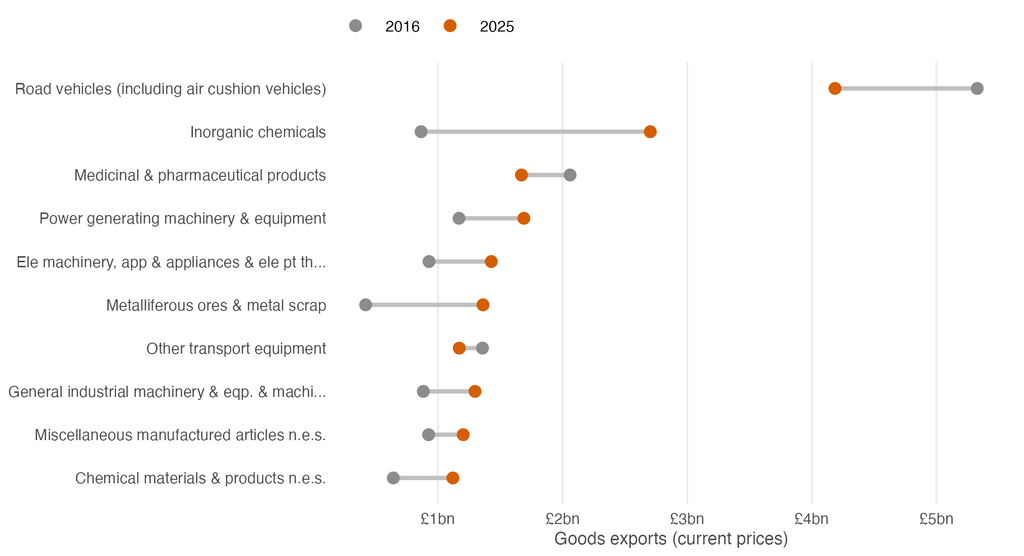

Figure 35: North West goods exports by product group, 2016 and 2025. North West goods exports by SITC division, the ten largest in 2025 , £ billion. HMRC allocates trade to regions by where businesses employ people. Source: HMRC, HMRC Regional Trade Statistics (2026-Q2).

In 2023, LCR exported £6.5bn of goods and £5.4bn of services (excluding travel), or £7,495 per resident; 45.9% of its goods exports went to the EU. Figure 36 compares the nine English combined authorities in ONS’s 2023 city-region geography. It has North of Tyne in place of today’s North East, and none of the authorities set up in 2024-25. ONS suppresses some services figures.

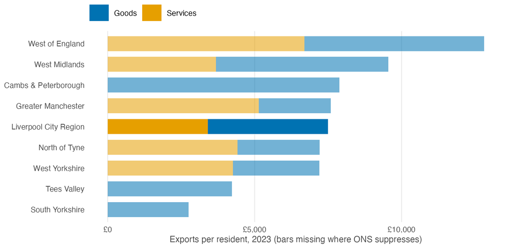

Figure 36: Exports per resident by combined authority, 2023. Exports of goods and of services (excluding travel) by combined authority, 2023, per resident. ONS suppresses some cells ([c]). Source: ONS, Subnational trade in goods (released 6 August 2025); ONS, Subnational trade in services (released 6 August 2025); ONS via Nomis, Population estimates (local authority based) (released 29 July 2026).

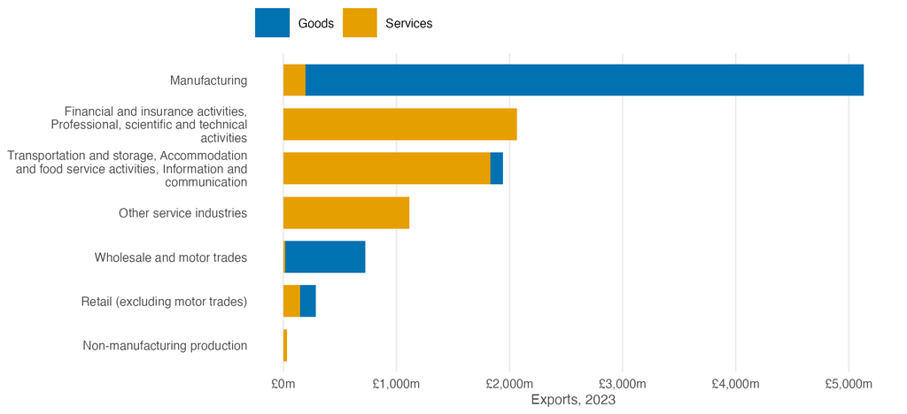

Figure 37: LCR exports by industry group, 2023. LCR exports by industry group, goods and services, 2023, £ million. ONS suppresses some cells ([c]). Source: ONS, Subnational trade in goods (released 6 August 2025); ONS, Subnational trade in services (released 6 August 2025).

Text checked against the data build of 29 September 2026.

# 11 What SIA1 and SIA2 said, and what the data say now

SIA1 and SIA2 quoted many figures. This section takes 43 of the headline ones, with their page references, and sets each against the same measure for the same period in today’s releases, and against the latest figure (Table 9). Differences have three possible causes:

- **Revisions:** official statistics are revised, sometimes a lot. Regional GVA and population estimates both changed substantially after SIA2.
- **Definitions:** some measures have changed or been discontinued. The income-approach GVA SIA1 used no longer exists, and qualifications moved from NVQ to RQF levels in 2022.
- **Unstated methods:** some figures don’t say how they were made, so they can’t be checked exactly.

Of the 43 figures:

- 10 are reproduced within 0.5%, and 12 more are within 3%;
- 2 are reproduced exactly in the original release SIA2 used, which is held here;
- 14 differ by more than 3%, each with a note below;
- 1 is mislabelled;
- 2 can only be set against the latest figure, and 2 can’t be checked with the pipeline’s sources.

Three findings matter most for SIA3:

1. **The “broadly flat” real GVA in SIA2 no longer holds.** The June 2021 release SIA2 used reproduces its £32.85bn and 3.7% growth from 2006 to 2019 exactly. Today’s release puts that growth at 10.5% (Section 5).
2. **The “Advanced Manufacturing” figure in SIA1 is all of manufacturing.** The 47,000 jobs match all of manufacturing (SIC 10-33), not the technology-based definitions, which give about 19,000 for 2015 (Section 7).
3. **Some figures can’t be traced.** The share of science, research, engineering and technology professionals in SIA2 (6.8% in 2021) can’t be reproduced on either occupation classification, and its estimate that LCR accounted for about 2% of UK R&D spending has no published source at that level.

Table 9: Figures quoted by SIA1 and SIA2, checked against today’s data. Figures quoted in SIA1 (2017) and SIA2 (2022), with page references, against the same measure for the same period in today’s releases, and the latest figure. Status: Reproduced within 0.5%, Close within 3%, otherwise Differs; ranks must match exactly. Pages as printed, or PDF pages where stated. Source: ONS via Nomis, Population estimates (local authority based) (released 29 July 2026); ONS via Nomis, BRES open access (2015 on) (released 28 October 2025); ONS via Nomis, BRES 2009-2015 (excluding PAYE-only units) (released 28 September 2016); ONS, Regional GVA (balanced) by industry: local authorities (released 23 September 2026); ONS, Regional GVA (balanced) by industry: all ITL regions (released 11 June 2021, version 7; 23 September 2026); ONS, Regional gross disposable household income: local authorities (released 19 August 2026); ONS, Subregional productivity: local authorities (released 19 June 2025); ONS via Nomis, Annual Population Survey (variables) (released 21 July 2026); ONS via Nomis, UK Business Counts: enterprises (released 24 September 2026); ONS via Nomis, ASHE workplace analysis (released 3 November 2025); ONS, GERD (official statistics) (released 15 August 2025); European Commission, CORDIS Horizon 2020 projects and participants (released 22 September 2026); HEFCE, REF 2014 results (SIA1 vintage) (REF2014); UKRI (Research England), REF 2021 results (REF2021).

| Source | Claim | Cited | Same period, today | Latest | Status |
| --- | --- | --- | --- | --- | --- |
| SIA1, F17 p.2 | "a population of 1.53m people (ONS, MYE 2016)" | 1.530m (2015) | 1.518m | 1.611m (2025) | Close |
| SIA1, F17 p.2 | "an economy generating £29.4 billion Gross Value Added in 2015 (ONS, GVA 2016)" | £29.40bn (2015) | £30.56bn | £45.95bn (2024) | Differs |
| SIA1, F17 p.2 | "providing employment for 612,000 workers (ONS, BRES - Total Employment)" | 612,000 (2015) | 619,000 | 684,000 (2024) | Close |
| SIA1, F17 p.3 | "GVA per head (LCR=£18,472, UK =£25,351 GVA) ONS, GVA 2016" | £18,472 (2015) | £20,128 | £28,664 (2024) | Differs |
| SIA1, F17 p.3 | UK GVA per head of £25,351 (the comparator for the LCR figure) | £25,351 (2015) | £26,278 | £37,202 (2024) | Differs |
| SIA1, F17 p.3 | "Gross Domestic Household Income in LCR is £15,415 ... (UK=£17,965) (ONS, GDHI 2016)" | £15,415 (2014) | £15,323 | £21,535 (2024) | Close |
| SIA1, F17 p.5 | "GVA per job filled, was £43,250 in 2015" | £43,250 (2015) | £46,527 | £57,622 (2023) | Differs |
| SIA1, F17 p.5 | "below the average for England of £50,715" | £50,715 (2015) | £53,432 | £67,531 (2023) | Differs |
| SIA1, F17 PDF p.79 | Business density of 38.7 (businesses per 1,000 residents of working age), against 61.0 for England | 38.7 (2016) | 40.5 | 43.0 (2026) | Differs |
| SIA1, F17 PDF p.79 | "Employment rate 68.4%" (APS, January-December 2016) | 68.4% (2016) | 68.4% | 72.7% (2025) | Reproduced |
| SIA1, F17 PDF p.79 | "Earnings by place of work (weekly gross pay, £) 504.10" | £504.10 (2016) | £503.20 | £600.00 (2022) | Reproduced |
| SIA1, F17 p.11-12 | "[North West] gross expenditure [on R&D] in all sectors in 2014 was £2,557m, which is 8.3% of UK total R&D" | £2.56bn (2014) |  | £6.11bn (2023) | Latest only |
| SIA1, F17 p.6 | Table 1-3: Advanced Manufacturing, 47,000 jobs (Total Employment 2015) | 47,000 (2015) | 47,975 | 46,015 (2024) | Mislabelled |
| SIA1, F17 p.40 | UoL Chemistry: "99.2% of outputs classified as 4* or 3* - the best performance nationally" | 99.2% (REF2014) | 99.2% | 99.2% (REF2014) | Reproduced |
| SIA1, F17 p.26 | Clinical Medicine (joint UoL and LSTM submission): "16.4% of outputs were rated 4*" | 16.4% (REF2014) | 16.4% | 16.4% (REF2014) | Reproduced |
| SIA2, R22 p.5 | "The LCR population increased to 1.564 million in 2020" | 1.564m (2020) | 1.546m | 1.611m (2025) | Close |
| SIA2, R22 p.5 | "The economic activity rate for residents aged 16-64 increased to 77.1% in 2021" | 77.1% (2021) | 77.3% | 76.5% (2025) | Reproduced |
| SIA2, R22 p.5 | "the unemployment rate reduced to 4.6% in 2021" | 4.6% (2021) | 4.5% | 4.9% (2025) | Close |
| SIA2, R22 p.5 | "Total employment in LCR increased to 651,000 in 2020" | 651,000 (2020) | 651,000 | 684,000 (2024) | Reproduced |
| SIA2, R22 p.5 | "the median gross pay for full time LCR workers was £29.6k p.a." (2021) | £29,600 (2021) | £29,781 | £31,002 (2022) | Close |
| SIA2, R22 p.6 | "indexed (to UK=100) nominal smoothed GVA per hour worked was 86.2 by 2019" | 86.2 (2019) | 86.9 | 89.0 (2023) | Close |
| SIA2, R22 p.6 | "down from a peak of 95.1 in 2009" | 95.1 (2009) | 94.5 | 89.0 (2023) | Close |
| SIA2, R22 p.6 | "LCR's total GVA of £32.85 billion in 2019 (in 2018 prices)" | £32.85bn (2019) | £41.44bn | £44.70bn (2024) | Reproduced in original release |
| SIA2, R22 p.6 | "3.7% higher than in 2006" | 3.7% (2006-2019) | 10.5% | 19.2% (2024) | Reproduced in original release; revised since |
| SIA2, R22 p.7 | "The proportion of residents aged 16-64 with NVQ4+ (degree level) skills increased to 39.1% in 2021" | 39.1% (2021) | 39.4% | 44.2% (2025 (RQF)) | Close |
| SIA2, R22 p.7 | "the proportion with no qualifications decreased to 7.7%" (2021) | 7.7% (2021) | 7.9% | 8.9% (2025 (RQF)) | Close |
| SIA2, R22 p.7 | "the number of enrolled students increased to 63,295 in 2020/21" | 63,295 (2020/21) |  |  | Not checked |
| SIA2, R22 p.7 | "the City Region's share of UK expenditure on R&D was broadly flat at about 2% over the decade to 2018" | 2.0% (2008-2018) |  |  | Not checked |
| SIA2, R22 p.7 | "the North West's share has been decreasing: down to 7.7% in 2019" | 7.7% (2019) |  | 8.4% (2023) | Latest only |
| SIA2, R22 p.7 | Horizon 2020 funding "peaked at EUR21.8 million in 2016" | €21.8m (2016) | €20.4m | €11.1m (2020) | Differs |
| SIA2, R22 p.7 | Horizon 2020 funding "reduced to EUR12.8 million by 2020" | €12.8m (2020) | €11.1m | €11.1m (2020) | Differs |
| SIA2, R22 p.8 | Science, research, engineering and technology professionals: "6.8% for LCR in 2021" | 6.8% (2021) | 5.3% | 7.9% (2025 (SOC 2020)) | Differs |
| SIA2, R22 p.11 | "20: Manufacture of chemicals and chemical products ... LQ vs GB 2.32" (2020) | 2.32 (2020) | 2.32 | 2.55 (2024) | Reproduced |
| SIA2, R22 p.11 | "29: Manufacture of motor vehicles, trailers and semi-trailers ... 2.03" (2020) | 2.03 (2020) | 2.03 | 1.68 (2024) | Reproduced |
| SIA2, R22 p.11 | "86: Human health activities ... 1.54" (2020) | 1.54 (2020) | 1.56 | 1.57 (2024) | Close |
| SIA2, R22 p.12 | "62: Computer programming, consultancy, and related activities ... 0.50" (2020) | 0.50 (2020) | 0.49 | 0.45 (2024) | Close |
| SIA2, R22 p.8 | REF 2021 GPA rank: LSTM 12th | 12th (REF2021) | 15th | 15th (REF2021) | Differs |
| SIA2, R22 p.8 | REF 2021 GPA rank: UoL 25th | 25th (REF2021) | 31st | 31st (REF2021) | Differs |
| SIA2, R22 p.8 | REF 2021 GPA rank: LJMU 82nd | 82nd (REF2021) | 98th | 98th (REF2021) | Differs |
| SIA2, R22 p.8 | REF 2021 research power rank: UoL 19th | 19th (REF2021) | 19th | 19th (REF2021) | Reproduced |
| SIA2, R22 p.8 | REF 2021 research power rank: LJMU 46th | 46th (REF2021) | 46th | 46th (REF2021) | Reproduced |
| SIA2, R22 p.8 | REF 2021 research power rank: Liverpool Hope 97th | 97th (REF2021) | 99th | 99th (REF2021) | Differs |
| SIA2, R22 p.8 | REF 2021 research power rank: LSTM 110th | 110th (REF2021) | 115th | 115th (REF2021) | Differs |

## 11.1 Notes on each figure

- **SIA1, F17 p.2** (Close): The 2016 release covered mid-2015. Estimates for 2012-2020 were revised after Census 2021.
- **SIA1, F17 p.2** (Differs): The 2016 release used the income approach, since discontinued; today’s figure is balanced GVA at current prices.
- **SIA1, F17 p.2** (Close): BRES year not stated; 2015 assumed (the latest BRES year in 2017).
- **SIA1, F17 p.3** (Differs): Income-approach GVA in 2016; balanced GVA today.
- **SIA1, F17 p.3** (Differs): Income-approach GVA in 2016; balanced GVA today.
- **SIA1, F17 p.3** (Close): The 2016 release covered 2014. GDHI is revised every year.
- **SIA1, F17 p.5** (Differs): Taken from the Northern Powerhouse Independent Economic Review (2016); today’s figure is ONS’s smoothed GVA per filled job, hours-weighted from local authorities.
- **SIA1, F17 p.5** (Differs): Northern Powerhouse Independent Economic Review; today’s figure is ONS’s smoothed GVA per filled job.
- **SIA1, F17 PDF p.79** (Differs): Assumed to be UK Business Counts enterprises (March 2016) per 1,000 residents aged 16-64; the SIA1 table doesn’t give its sources for this row.
- **SIA1, F17 PDF p.79** (Reproduced): APS estimates are reweighted from time to time.
- **SIA1, F17 PDF p.79** (Reproduced): Assumed to be median gross weekly pay of full-time employees, by workplace, for the LCR LEP area (the same six local authorities).
- **SIA1, F17 p.11-12** (Latest only): The pipeline holds GERD for 2022 and 2023 only, so only the latest figure is shown.
- **SIA1, F17 p.6** (Mislabelled): Mislabelled: the figure is all of manufacturing (SIC 10-33). The Industrial Strategy (IS-8) definition gives about 19,000 in 2015 (see LCR_sector_figures_check.md). Nomis gives 47,975 for LCR as a combined authority; the six local authorities sum to 46,925, because BRES rounds each published figure.
- **SIA1, F17 p.40** (Reproduced): Outputs profile of the University of Liverpool’s Chemistry submission.
- **SIA1, F17 p.26** (Reproduced): Outputs profile of the Clinical Medicine submission; REF data list it under LSTM.
- **SIA2, R22 p.5** (Close): Estimates for 2012-2020 were revised after Census 2021.
- **SIA2, R22 p.5** (Reproduced): APS estimates are reweighted from time to time.
- **SIA2, R22 p.5** (Close): APS estimates are reweighted from time to time.
- **SIA2, R22 p.5** (Close): LCR LEP area (the same six local authorities), by workplace. Nomis’s LEP figures stop at 2022.
- **SIA2, R22 p.6** (Close): Today’s figure is hours-weighted from ONS’s local-authority productivity tables.
- **SIA2, R22 p.6** (Close): Today’s figure is hours-weighted from ONS’s local-authority productivity tables.
- **SIA2, R22 p.6** (Reproduced in original release): Reproduced exactly by the June 2021 release. Today’s release prices volumes in 2023 money, so the level isn’t comparable; see the growth row.
- **SIA2, R22 p.6** (Reproduced in original release; revised since): Growth is comparable across releases even though the price base changed.
- **SIA2, R22 p.7** (Close): Qualifications moved to RQF levels in 2022; the latest figure is RQF4+ and isn’t directly comparable.
- **SIA2, R22 p.7** (Close): Qualifications moved to RQF levels in 2022; the latest figure is on the RQF basis.
- **SIA2, R22 p.7** (Not checked): Not checked: HESA data are a manual download not yet in the pipeline.
- **SIA2, R22 p.7** (Not checked): Not checked: ONS publishes GERD only for ITL1 regions; SIA2 doesn’t say how the LCR share was estimated.
- **SIA2, R22 p.7** (Latest only): The pipeline holds GERD for 2022 and 2023 only.
- **SIA2, R22 p.7** (Differs): EU contribution to participants in Merseyside (ITL2 TLD7), by project start year. CORDIS data change as projects run, and SIA2 doesn’t say how it dated projects.
- **SIA2, R22 p.7** (Differs): EU contribution to participants in Merseyside (ITL2 TLD7), by project start year. CORDIS data change as projects run, and SIA2 doesn’t say how it dated projects.
- **SIA2, R22 p.8** (Differs): Not reproduced on either basis for January-December 2021: 5.3% on SOC 2010 and 5.7% on SOC 2020. SIA2 may have used another period or an earlier APS weighting; its note 16 gives no detail.
- **SIA2, R22 p.11** (Reproduced): BRES employment share relative to Great Britain.
- **SIA2, R22 p.11** (Reproduced): BRES employment share relative to Great Britain.
- **SIA2, R22 p.11** (Close): BRES employment share relative to Great Britain.
- **SIA2, R22 p.12** (Close): BRES employment share relative to Great Britain.
- **SIA2, R22 p.8** (Differs): Times Higher Education method (FTE-weighted overall GPA). Ranks here include every institution in the REF 2021 data; published league tables exclude or merge some, which moves GPA ranks more than research power ranks.
- **SIA2, R22 p.8** (Differs): As for LSTM: ranks here include every institution in the REF 2021 data, so GPA ranks differ from published league tables.
- **SIA2, R22 p.8** (Differs): As for LSTM: ranks here include every institution in the REF 2021 data, so GPA ranks differ from published league tables.
- **SIA2, R22 p.8** (Reproduced): Research power = GPA x FTE staff submitted.
- **SIA2, R22 p.8** (Reproduced): Research power = GPA x FTE staff submitted.
- **SIA2, R22 p.8** (Differs): Research power = GPA x FTE staff submitted. Ranks here include every institution in the REF 2021 data.
- **SIA2, R22 p.8** (Differs): Research power = GPA x FTE staff submitted. Ranks here include every institution in the REF 2021 data.

Text checked against the data build of 29 September 2026.

# 12 Gaps and caveats

## 12.1 Sources not covered

24 of the register’s sources have no processed data yet (Table 10). Most are documents, licensed data or the audits’ own consultations, which no script can reach. The rest are waiting for an API key (OpenAlex), a manual download (HESA, G-FINDER, Global Burden of Disease), or a processing step not yet built (Companies House, Gateway to Research, OECD TiVA).

Table 10: Sources in the register that this report doesn’t use yet. Sources in the register with no processed data yet. Source: the pipeline’s source register (R/source_register.csv) and update check (data/source_status.csv).

| Source | SIA evidence item | Role | Status |
| --- | --- | --- | --- |
| OpenAlex (replacement for SciVal) | SciVal / Scopus bibliometrics | Replacement for an SIA source | needs key |
| SciVal / Scopus as used by SIA1 | SciVal / Scopus bibliometrics | Used by SIA1 or SIA2 | manual |
| HEFCE REF-metrics correlation analysis (2015) | REF-metrics correlation analysis | Used by SIA1 or SIA2 | manual |
| Patent applications (Technopolis analysis) | Patent applications | Used by SIA1 or SIA2 | manual |
| University grant data by funder type | University grant data by funder type | Used by SIA1 or SIA2 | manual |
| UKRI Gateway to Research (replacement) | University grant data by funder type | Replacement for an SIA source | live API |
| HESA finance: research income by source (replacement) | University grant data by funder type | Replacement for an SIA source | manual |
| G-FINDER neglected disease R&D | Neglected-disease R&D (G-Finder) | Used by SIA1 or SIA2 | manual |
| Regional GVA (income approach) - discontinued | Regional GVA; sub-regional productivity | Used by SIA1 or SIA2 | up to date |
| HESA student enrolments | HE student enrolments | Used by SIA1 or SIA2 | manual |
| State of the LCR Report (2016) | State of the Liverpool City Region Report | Used by SIA1 or SIA2 | manual |
| Northern Powerhouse Independent Economic Review (2016) | Northern Powerhouse Independent Economic Review | Used by SIA1 or SIA2 | manual |
| ERC growth dashboard | Enterprise Research Centre growth dashboard | Used by SIA1 or SIA2 | manual |
| Oxford Economics LCR forecasts | LCR growth forecasts | Used by SIA1 or SIA2 | manual |
| OECD TiVA 2025 edition: principal indicators | Trade in Value Added (TiVA) | Used by SIA1 or SIA2 | checked only |
| Global Burden of Disease results | Global Burden of Disease | Used by SIA1 or SIA2 | manual |
| Commercial market reports | Market reports | Used by SIA1 or SIA2 | manual |
| Chemistry Growth Strategy Group report (2013) | Chemistry Growth Strategy Group | Used by SIA1 or SIA2 | manual |
| Companies House basic company data (replacement for the firm scrape) | HP&CC firm scrape | Replacement for an SIA source | checked only |
| HP&CC firm scrape (commissioned by Hartree) | HP&CC firm scrape | Used by SIA1 or SIA2 | manual |
| Organisations' own figures | Figures reported by organisations | Used by SIA1 or SIA2 | manual |
| LCR strategy documents | LCR strategy documents | Used by SIA1 or SIA2 | manual |
| Stakeholder engagement | Stakeholder engagement | Used by SIA1 or SIA2 | manual |
| HESA Higher Education Business and Community Interaction survey | (new) Knowledge exchange | Addition (not used by SIA1 or SIA2) | manual |

## 12.2 Data caveats

- **GVA for West of England and parts of the South West, Wales and Scotland.** ONS suppressed these in its September 2026 release, after an error converting to the ITL 2025 regions, and expects a corrected release within four to six weeks. West of England is missing from the GVA comparisons here, and England and UK totals come from ONS’s regional (ITL1) table, which is unaffected. The pipeline’s update check will flag the corrected release.
- **Revisions.** GVA, GDHI, productivity and population estimates are revised every year, and population estimates for 2012 to 2020 were revised after Census 2021. Always compare years within one release.
- **Rounding.** BRES rounds every published figure, often to the nearest thousand for combined authorities. Summing local authorities gives slightly different totals from Nomis’s combined-authority figures.
- **Survey error.** Annual Population Survey figures for a single combined authority have confidence intervals of one to four percentage points; the labour-market charts show them where they matter.
- **Earnings.** No combined-authority earnings figure exists. Nomis publishes ASHE for local authorities, and its figures for the old LEP areas stop in 2022.
- **Geography changes.** Barnsley and Sheffield changed codes, and most sources still use the old ones; the pipeline maps them. The trade statistics use 2023 city regions, and CORDIS uses ITL 2021 regions.
- **R&D.** Total R&D spending is published only for regions such as the North West, so the SIA2 target of 5% of GVA can’t be tracked directly for LCR. Business R&D is published for ITL2 regions, including Merseyside.
- **EU funding.** The UK was not associated to Horizon Europe until January 2024, so UK figures for 2021 to 2023 are low for that reason.
- **Advanced manufacturing.** Only the Industrial Strategy’s advanced manufacturing sector is defined in the pipeline so far. Definitions of the other Industrial Strategy sectors are still to be decided.

The pipeline code records every known issue at the top of each module in `R/sources/` and `R/report/`.

# Appendix A: Data sources

Table 11 lists every source in the pipeline’s register, including those this report doesn’t use. For each processed source it gives the release used and the latest period in the data. The register, `R/source_register.csv`, holds each source’s web address, access method, coverage and issues.

Table 11: Every source in the pipeline register. Every source in the pipeline’s register, including those that can’t be scripted. Source: the pipeline’s source register (R/source_register.csv) and update check (data/source_status.csv).

| Source | Publisher | Role | Release used | Latest data | Licence |
| --- | --- | --- | --- | --- | --- |
| ASHE resident analysis | ONS via Nomis | Used by SIA1 or SIA2 | 3 November 2025 | 2025 | Open Government Licence v3.0 |
| ASHE workplace analysis | ONS via Nomis | Used by SIA1 or SIA2 | 3 November 2025 | 2025 | Open Government Licence v3.0 |
| Jobs density | ONS via Nomis | Used by SIA1 or SIA2 | 21 April 2026 | 2024 | Open Government Licence v3.0 |
| Regional gross disposable household income: local authorities | ONS | Used by SIA1 or SIA2 | 19 August 2026 | 2024 | Open Government Licence v3.0 |
| Annual Population Survey (variables) | ONS via Nomis | Used by SIA1 or SIA2 | 21 July 2026 | Apr 2025-Mar 2026 | Open Government Licence v3.0 |
| BRES 2009-2015 (excluding PAYE-only units) | ONS via Nomis | Used by SIA1 or SIA2 | 28 September 2016 | 2014 | Open Government Licence v3.0 |
| BRES open access (2015 on) | ONS via Nomis | Used by SIA1 or SIA2 | 28 October 2025 | 2024 | Open Government Licence v3.0 |
| BERD (official statistics) | ONS | Used by SIA1 or SIA2 | 28 November 2025 | 2024 | Open Government Licence v3.0 |
| Business demography (annual) | ONS | Used by SIA1 or SIA2 | 20 November 2025 | 2024 | Open Government Licence v3.0 |
| UK Business Counts: enterprises | ONS via Nomis | Used by SIA1 or SIA2 | 24 September 2026 | 2026 | Open Government Licence v3.0 |
| UK Business Counts: local units | ONS via Nomis | Used by SIA1 or SIA2 | 24 September 2026 | 2026 | Open Government Licence v3.0 |
| Chemistry Growth Strategy Group report (2013) | CGSG | Used by SIA1 or SIA2 | - | - | Published report (cite) |
| ERC growth dashboard | Enterprise Research Centre | Used by SIA1 or SIA2 | - | - | Check terms (Enterprise Research Centre) |
| Organisations' own figures | various | Used by SIA1 or SIA2 | - | - | Not public |
| Global Burden of Disease results | IHME | Used by SIA1 or SIA2 | - | - | IHME free-of-charge non-commercial user agreement |
| HESA student enrolments | HESA | Used by SIA1 or SIA2 | - | - | CC BY 4.0 |
| HP&CC firm scrape (commissioned by Hartree) | Hartree Centre | Used by SIA1 or SIA2 | - | - | Not public |
| CORDIS Horizon 2020 projects and participants | European Commission | Used by SIA1 or SIA2 | 22 September 2026 | 2023 | CC BY 4.0 |
| English Indices of Deprivation 2015 (SIA1 vintage) | DCLG | Used by SIA1 or SIA2 | 30 September 2015 | 2015 | Open Government Licence v3.0 |
| OECD Main Science and Technology Indicators | OECD | Used by SIA1 or SIA2 | 19 June 2026 | 2025 | CC BY 4.0 |
| Oxford Economics LCR forecasts | Oxford Economics (for the LEP / CA) | Used by SIA1 or SIA2 | - | - | Proprietary (Oxford Economics) |
| LCR strategy documents | LCR CA / LEP | Used by SIA1 or SIA2 | - | - | Published documents (cite) |
| Commercial market reports | various | Used by SIA1 or SIA2 | - | - | Proprietary |
| Population estimates (local authority based) | ONS via Nomis | Used by SIA1 or SIA2 | 29 July 2026 | 2025 | Open Government Licence v3.0 |
| G-FINDER neglected disease R&D | Impact Global Health | Used by SIA1 or SIA2 | - | - | Check terms (Policy Cures Research) |
| Northern Powerhouse Independent Economic Review (2016) | Transport for the North | Used by SIA1 or SIA2 | - | - | Published report (cite) |
| Patent applications (Technopolis analysis) | Technopolis | Used by SIA1 or SIA2 | - | - | Not public |
| HEFCE REF-metrics correlation analysis (2015) | HEFCE | Used by SIA1 or SIA2 | - | - | Published report (cite) |
| Regional GVA (balanced) by industry: all ITL regions | ONS | Used by SIA1 or SIA2 | 23 September 2026 | 2024 | Open Government Licence v3.0 |
| Regional GVA (income approach) - discontinued | ONS | Used by SIA1 or SIA2 | - | - | Open Government Licence v3.0 |
| Subregional productivity: ITL2 and ITL3 | ONS | Used by SIA1 or SIA2 | 19 June 2025 | 2023 | Open Government Licence v3.0 |
| Subregional productivity: city regions | ONS | Used by SIA1 or SIA2 | 17 June 2024 | 2022 | Open Government Licence v3.0 |
| GERD (official statistics) | ONS | Used by SIA1 or SIA2 | 15 August 2025 | 2023 | Open Government Licence v3.0 |
| HMRC Regional Trade Statistics | HMRC | Used by SIA1 or SIA2 | 2026-Q2 | 2026 | Open Government Licence v3.0 |
| REF 2014 results (SIA1 vintage) | HEFCE | Used by SIA1 or SIA2 | REF2014 | REF2014 | Not stated on the results site; check before publishing |
| REF 2021 results | UKRI (Research England) | Used by SIA1 or SIA2 | REF2021 | REF2021 | Not stated on the results site; check before publishing |
| SciVal / Scopus as used by SIA1 | Elsevier | Used by SIA1 or SIA2 | - | - | Proprietary (Elsevier subscription) |
| Stakeholder engagement |  | Used by SIA1 or SIA2 | - | - | Not public |
| State of the LCR Report (2016) | UoL / LJMU | Used by SIA1 or SIA2 | - | - | Published report (cite) |
| OECD TiVA 2025 edition: principal indicators | OECD | Used by SIA1 or SIA2 | - | - | CC BY 4.0 |
| University grant data by funder type | UoL, LSTM, LJMU | Used by SIA1 or SIA2 | - | - | Not public |
| CORDIS Horizon Europe projects and participants | European Commission | Later edition of an SIA source | 22 September 2026 | 2027 | CC BY 4.0 |
| English Indices of Deprivation 2019 | MHCLG | Later edition of an SIA source | 26 September 2019 | 2019 | Open Government Licence v3.0 |
| English Indices of Deprivation 2025 | MHCLG | Later edition of an SIA source | 17 November 2025 | 2025 | Open Government Licence v3.0 |
| Regional GVA (balanced) by industry: local authorities | ONS | Related table from an SIA source | 23 September 2026 | 2024 | Open Government Licence v3.0 |
| Subregional productivity: local authorities | ONS | Related table from an SIA source | 19 June 2025 | 2023 | Open Government Licence v3.0 |
| Companies House basic company data (replacement for the firm scrape) | Companies House | Replacement for an SIA source | - | - | Open Government Licence v3.0 |
| OpenAlex (replacement for SciVal) | OurResearch | Replacement for an SIA source | - | - | CC0 |
| HESA finance: research income by source (replacement) | HESA | Replacement for an SIA source | - | - | CC BY 4.0 |
| UKRI Gateway to Research (replacement) | UKRI | Replacement for an SIA source | - | - | Open Government Licence v3.0 |
| Innovate UK funded projects since 2004 | UKRI | Addition (not used by SIA1 or SIA2) | 2 September 2026 | 2026/27 | Open Government Licence v3.0 |
| HESA Higher Education Business and Community Interaction survey | HESA | Addition (not used by SIA1 or SIA2) | - | - | CC BY 4.0 |
| Public-funded regional R&D spending | ONS | Addition (not used by SIA1 or SIA2) | 25 June 2024 | FYE 2022 | Open Government Licence v3.0 |
| Subnational trade in goods | ONS | Addition (not used by SIA1 or SIA2) | 6 August 2025 | 2023 | Open Government Licence v3.0 |
| Subnational trade in services | ONS | Addition (not used by SIA1 or SIA2) | 6 August 2025 | 2023 | Open Government Licence v3.0 |
| ONS geography lookups (LA to combined authority, LA to ITL) | ONS | Geography lookup | 4 December 2025 | - | Open Government Licence v3.0 |

## Web addresses

- CORDIS Horizon 2020 projects and participants: https://cordis.europa.eu/data/cordis-h2020projects-csv.zip
- CORDIS Horizon Europe projects and participants: https://cordis.europa.eu/data/cordis-HORIZONprojects-csv.zip
- Companies House basic company data (replacement for the firm scrape): https://download.companieshouse.gov.uk/en_output.html
- G-FINDER neglected disease R&D: https://gfinderdata.impactglobalhealth.org/
- Global Burden of Disease results: https://vizhub.healthdata.org/gbd-results/
- HESA Higher Education Business and Community Interaction survey: https://www.hesa.ac.uk/data-and-analysis/business-community
- HESA finance: research income by source (replacement): https://www.hesa.ac.uk/data-and-analysis/finances
- HESA student enrolments: https://www.hesa.ac.uk/data-and-analysis/students
- HMRC Regional Trade Statistics: https://api.uktradeinfo.com/RTS
- Innovate UK funded projects since 2004: https://www.ukri.org/publications/innovate-uk-funded-projects-since-2004/
- ONS geography lookups (LA to combined authority, LA to ITL): https://geoportal.statistics.gov.uk/
- OpenAlex (replacement for SciVal): https://api.openalex.org
- REF 2014 results (SIA1 vintage): https://results.ref.ac.uk/
- REF 2021 results: https://results2021.ref.ac.uk/profiles/export-all
- UKRI Gateway to Research (replacement): https://gtr.ukri.org/gtr/api/projects

# Appendix B: Definitions

## Areas

LCR is the six local authorities of the Liverpool City Region Combined Authority (E47000004): Halton (E06000006), Knowsley (E08000011), Liverpool (E08000012), St Helens (E08000013), Sefton (E08000014) and Wirral (E08000015). The same six make up the ITL2 region TLD7, Merseyside, and made up the Liverpool City Region LEP area (E37000022) until LEPs were wound down.

Table 12 lists the 15 combined authorities and the group each is drawn in. “Established” means the authority had an elected mayor by 2021. The North East counts through its predecessor, the North of Tyne Combined Authority (mayor from 2019).

Table 12: The 15 combined authorities in England (ONS lookup, May 2025) and their chart groups.

| Code | Combined authority | Group |
| --- | --- | --- |
| E47000004 | Liverpool City Region | Liverpool City Region |
| E47000008 | Cambs & Peterborough | Established (mayor by 2021) |
| E47000001 | Greater Manchester | Established (mayor by 2021) |
| E47000014 | North East | Established (mayor by 2021) |
| E47000002 | South Yorkshire | Established (mayor by 2021) |
| E47000006 | Tees Valley | Established (mayor by 2021) |
| E47000007 | West Midlands | Established (mayor by 2021) |
| E47000003 | West Yorkshire | Established (mayor by 2021) |
| E47000009 | West of England | Established (mayor by 2021) |
| E47000015 | Devon & Torbay | Newer (set up 2024-25) |
| E47000013 | East Midlands | Newer (set up 2024-25) |
| E47000017 | Greater Lincolnshire | Newer (set up 2024-25) |
| E47000016 | Hull & E Yorkshire | Newer (set up 2024-25) |
| E47000018 | Lancashire | Newer (set up 2024-25) |
| E47000012 | York & N Yorkshire | Newer (set up 2024-25) |

## Headline measures

Table 13: Definitions of the headline measures in section 3.

| Measure | Definition | Unit | Source |
| --- | --- | --- | --- |
| Population | Mid-year estimate, all ages | people | nomis_mye |
| Employment (BRES) | Employees + working owners, all industries | jobs | nomis_bres |
| Manufacturing share of employment | SIC 10-33 / all industries (BRES) | % | nomis_bres |
| Advanced manufacturing employment (IS-8) | SIC 20, 26-30: DBT Industrial Strategy definition (BRES) | jobs | nomis_bres |
| Advanced manufacturing share (IS-8) | SIC 20, 26-30 / all industries (BRES) | % | nomis_bres |
| Employment rate 16-64 | APS, calendar year | % | nomis_aps |
| Qualified to RQF level 4+ (16-64) | APS, calendar year | % | nomis_aps |
| GVA (current prices) | Balanced GVA, sum of local authorities; England and UK from the ITL1 table | £ million | ons_gva_la |
| GVA per head | Balanced GVA / mid-year population, same year | £ | ons_gva_la |
| GVA per hour worked | Smoothed current-price GVA per hour, hours-weighted across local authorities | £ | ons_productivity_la |
| GDHI per head | Gross disposable household income / population (ONS GDHI tables) | £ | ons_gdhi_la |
| LSOAs in England's most deprived 10% | IMD 2025 decile 1, share of LSOAs | % | govuk_iod2025 |
| Enterprises per 10,000 residents aged 16-64 | UK Business Counts (March) / mid-year population 16-64 | per 10,000 | nomis_ukbc_enterprises |
| High-growth enterprise rate | High-growth enterprises / active enterprises with 10+ employees | % | ons_business_demography |
| Innovate UK awards, last 5 years | Award offered to participants, by competition financial year | £ million | ukri_innovate_uk |
| Innovate UK awards per head, last 5 years | Award offered / latest mid-year population | £ | ukri_innovate_uk |

## Sectors

- **All manufacturing:** SIC 2007 divisions 10 to 33.
- **High and medium-high technology manufacturing (approximation):** divisions 20, 21 and 26 to 30. Eurostat’s own definition uses some 3-digit groups; whole divisions are used here because BRES publishes divisions for all areas.
- **Advanced manufacturing (Industrial Strategy, IS-8):** divisions 20 and 26 to 30. This is the government’s version of the Eurostat and UN definitions, with pharmaceuticals (21) moved to Life Sciences.

## Derived measures

- **Grade point average (GPA):** (4 × %4* + 3 × %3* + 2 × %2* + %1*) / 100. Institution GPA weights each unit’s overall GPA by its FTE staff (Times Higher Education method).
- **Research power:** GPA × FTE staff submitted.
- **Location quotient:** an area’s share of employment (or GVA) in an industry divided by the national share.
- **Per head:** divided by the mid-year population of the same year, unless a caption says otherwise.
- **Index (UK = 100):** an area’s value as a percentage of the UK value in the same year.
- **Birth, death and survival rates:** births or deaths per 100 active enterprises; survival is the share of a year’s births still active three years later.

# Appendix C: Reproducibility

This report was rendered from the data build of 29 September 2026, which holds 48 report tables. Each table records its sources and releases; `report_manifest.csv` in the build folder lists them.

To rebuild from scratch, run these from the project folder:

```
Rscript R/01_check_sources.R       # check for new releases
Rscript R/02_fetch_sources.R       # download them (never overwrites)
Rscript R/03_process_sources.R     # tidy tables
Rscript R/04_build_comparisons.R   # combined-authority comparisons
Rscript R/05_build_report_data.R   # report tables (data/report/<date>/)
quarto render report/              # this report, HTML and PDF
```

To render an earlier build, pass its date: `quarto render report/sia_data_report.qmd -P build:2026-09-29`.

The figures in Section 11 come from `R/cited_figures.csv`, which is kept by hand. Each row quotes SIA1 or SIA2 with its page and names the measure used to check it.

Software: R version 4.5.1 (2025-06-13); dplyr 1.2.1, tidyr 1.3.1, ggplot2 4.0.0, tinytable 0.13.0, httr2 1.2.1, readxl 1.4.5; Quarto with Typst for the PDF.